# Code

Victoria Wang

10/22/2019

## Do Denser Ethnic Ties Affect Intrastate Conflict Contagion?

### Ethnic Kinship Network Transitivity and Intrastate Conflict Contagion

#### This notebook contains all the codes used to process/analyze data and establish models.

First, we read in all the packages we need.

```r
library(readr)
library(dplyr)
```

```r
library(ggplot2)
library(stringr)
library(igraph)
library(tidyverse)
library(visNetwork)
library(caret)
library(pscl)
library(reshape2)
library(lmtest)
```

## Construct Dataframe for Control Variables

I am merging multiple datasets, some coded countries with 3-char state abbreviation, others (i.e. UCDP datasets) coded countries with Gleditsch and Ward (GW) State Codes. I am using a dataset of 3-char state code and GW code as a reference to correctly combine the different datasets.

```
## # A tibble: 6 x 2
##   scode  gwid
##   <chr> <dbl>
## 1 USA       2
## 2 CAN      20
## 3 BHM      31
## 4 CUB      40
## 5 HAI      41
## 6 DOM      42
```

Below are the datasets that contain: 1. Dyadic transborder ethnic kinship data used to construct the network. 2. all the control variables I’ll be using for the model.

```r
# Read in all the necessary data
epr_raw <- read_csv("data/epr.csv")
tek_raw <- read_csv("data/tek.csv") # Dyad data
gdp_raw <- read_csv("data/gdp.csv") # GDP growth rates (I ended up not using it)
pcgdp_raw <- read_csv("data/pcgdp.csv") # Per-capita GDP
pol_scr_raw <- read_csv("data/pol_scr.csv") # Polity Score
war_raw <- read_csv("data/wars.csv") # Response variable: binary codes for state-year war incidence
```

```r
region <- read_csv('data/state_region.csv') # UN/World Bank-defined geographical categorization of states
# Process polity score data
pol_scr <- pol_scr_raw %>% filter(as.numeric(year) %in% 1960:2017) %>% select(scode, year, 'polity' = polity2)
head(pol_scr)
```

```
## # A tibble: 6 x 3
##   scode  year polity
##   <chr> <dbl>  <dbl>
## 1 USA    1960     10
## 2 USA    1961     10
## 3 USA    1962     10
## 4 USA    1963     10
## 5 USA    1964     10
## 6 USA    1965     10
```

```r
# Process per-capita GDP data
colnames(pcgdp_raw)[5] <- 1962
pcgdp <- melt(pcgdp_raw, id = c('statename', 'scode'))
colnames(pcgdp) <- c('statename', 'scode', 'year', 'pcgdp')
pcgdp$year <- as.numeric(substr(pcgdp$year, 0, 4))

mean <- pcgdp[pcgdp$pcgdp != '..',] %>% group_by(scode, statename) %>% summarize(mean = format(round(mean(as.numeric(pcgdp)), 2), nsmall = 2)) %>% ungroup()
pcgdp <- left_join(pcgdp, mean, by = c('scode', 'statename'))
pcgdp[pcgdp$pcgdp == '..', 4] <- pcgdp[pcgdp$pcgdp == '..', 5]

pcgdp <- pcgdp[,2:4]
pcgdp$pcgdp <- as.numeric(pcgdp$pcgdp)

tail(pcgdp)
```

```
##       scode year    pcgdp
## 15571   TSA 2018  1890.35
## 15572   SSF 2018  1656.93
## 15573   SSA 2018  1655.78
## 15574   TSS 2018  1656.93
## 15575   UMC 2018  8537.98
## 15576   WLD 2018 10881.14
```

```r
# Merge them into one dataset called war_final
war_final <- left_join(gwid, pol_scr, by = c('scode'))
war_final <- left_join(war_final, pcgdp, by = c('scode', 'year'))
war_final$pcgdp <- as.numeric(war_final$pcgdp)

# Process war data
war <- war_raw %>% filter(countries_gwid %in% war_final$gwid) %>% filter(year >= 1960) %>%
select(gwid = countries_gwid, year,
       statename = countryname, incidence_flag,
       incidence_terr_flag, incidence_gov_flag,
       incidence_eth_flag, incidence_terr_eth_flag,
       incidence_gov_eth_flag, warhist, peaceyears)

# Merge everything together
war_final <- left_join(war, war_final, by = c('gwid', 'year'))
head(war_final)
```

```
## # A tibble: 6 x 14
##    gwid  year statename incidence_flag incidence_terr_… incidence_gov_f…
##   <dbl> <dbl> <chr>              <dbl>            <dbl>            <dbl>
## 1     2  1960 United S…              0                0                0
## 2     2  1961 United S…              0                0                0
## 3     2  1962 United S…              0                0                0
## 4     2  1963 United S…              0                0                0
## 5     2  1964 United S…              0                0                0
## 6     2  1965 United S…              0                0                0
## # … with 8 more variables: incidence_eth_flag <dbl>,
## #   incidence_terr_eth_flag <dbl>, incidence_gov_eth_flag <dbl>,
## #   warhist <dbl>, peaceyears <dbl>, scode <chr>, polity <dbl>,
## #   pcgdp <dbl>
```

See how bad our missing values are.

```r
sapply(war_final, function(x) sum(is.na(x)))
```

```
##                    gwid                    year               statename
##                       0                       0                       0
##          incidence_flag     incidence_terr_flag      incidence_gov_flag
##                       0                       0                       0
##      incidence_eth_flag incidence_terr_eth_flag  incidence_gov_eth_flag
##                       0                       0                       0
##                 warhist              peaceyears                   scode
##                       0                       0                     662
##                  polity                   pcgdp
##                     753                    5240
```

## Construct Network Data

```r
# Add region variable to states
tek <- merge(tek_raw, region, by = 'statename', all = TRUE)
tek <- tek %>% filter(!is.na(tekid))

# Patch up missing values
tek[tek$statename %in% c('Brunei', 'Democratic People\'s Republic of Korea', 'Laos', 'Republic of Korea', 'Republic of Vietnam', 'Solomon Is.', 'Taiwan', 'Timor Leste'), "region"] <- 'East Asia and Pacific'
tek[tek$statename %in% c('Cape Verde', 'Congo', 'Congo, DRC', 'Cote d\'Ivoire', 'The Gambia'), "region"] <- 'Sub-Saharan Africa'
tek[tek$statename %in% c('Czechoslovakia', 'Germany Democratic Republic', 'Kyrgyzstan', 'Macedonia', 'Russia', 'Serbia and Montenegro', 'Slovakia'), "region"] <- 'Europe and Central Asia'
tek[tek$statename %in% c('Egypt', 'Iran', 'Libya (Tripolitania, Cyrenaica, Fezzan)', 'Syria', 'Yemen', 'Yemen People\'s Republic'), "region"] <- 'Middle East and North Africa'
tek[tek$statename %in% c('Guyana (British Guiana)', 'Venezuela'), "region"] <- 'Latin America and the Carribean'

# One tek group in a country may be under many names, so collapse them into one row
tek <- tek %>% group_by(statename, gwid, tekid, region) %>%
summarize(groupids = paste(gwgroupid, collapse = ", "), groupnames = paste(groupname, collapse = ", ")) %>% ungroup()
```

```r
# Use state IDs as nodes
nodes_world <- tek %>% select(gwid, statename, region)
nodes_world <- unique(nodes_world)
head(nodes_world)
```

```
## # A tibble: 6 x 3
##    gwid statename   region
##   <dbl> <chr>       <chr>
## 1   700 Afghanistan South Asia
## 2   339 Albania     Europe and Central Asia
## 3   615 Algeria     Middle East and North Africa
## 4   540 Angola      Sub-Saharan Africa
## 5   160 Argentina   Latin America and the Carribean
## 6   371 Armenia     Europe and Central Asia
```

```r
# Define a function that makes an edgelist for a set of TEK data
get_edge_list <- function(tekdata) {
    data_final = c()

    for (i in 1:nrow(tekdata)){

        # Preparations
        this_grp <- tekdata$tekid[i]
        this_name <- tekdata$groupnames[i]
        this_grpid <- tekdata$groupids[i]
        sid <- tekdata$gwid[i]
        sname <- tekdata$statename[i]

        temp <- tekdata %>% filter(tekid == this_grp, gwid != sid) %>% # Select foreign countries with the same TEK group
        filter(!(gwid %in% data_final$sourceid)) %>% # Select countries that have not gone through this loop
        mutate(sourceid = sid, sourcename = sname)
        temp$groupnames <- interaction(this_name, temp$groupnames, sep = ", ")
        temp$groupids <- interaction(this_grpid, temp$groupids, sep = ", ")
        data_final <- rbind(data_final, temp)
    }

    # Mark source and destination
    route <- data_final %>% select(tekid, groupids, groupnames, sourceid, sourcename, desid = gwid, desname = statename)
    #edges <- route %>% select(from = sourceid, to = desid)
    return(route)
}
```

Let’s have a look at today’s world in a TEK network!

```r
route_world <- get_edge_list(tek) # Make edgelist

# Construct network
nodes <- data.frame(id = nodes_world$gwid,
                    title = nodes_world$statename,
                    group = nodes_world$region)

edges <- data.frame(from = route_world$sourceid,
                    to = route_world$desid,
                    title = route_world$groupnames) # tooltip

# Have a look at the network
visNetwork(nodes, edges) %>%
visIgraphLayout(layout = "layout_with_fr") %>%
visInteraction(tooltipStyle = 'position: fixed; visibility: hidden; padding: 5px; white-space: nowrap; font-family: sans-serif; font-size: 14px; font-color: darkblue; background-color: lightblue;') %>%
visEdges(shadow = F,
         color = list(color = "lightblue", highlight = "darkblue")) %>%
visOptions(selectedBy = "group",
           highlightNearest = TRUE,
           nodesIdSelection = TRUE) %>%
visPhysics(stabilization = FALSE)
```

[interactive chart not shown]

```r
# Make an igraph object for all states across all years
g <- graph_from_data_frame(edges, directed = FALSE, vertices = nodes)
```

Just for fun, let’s visualize some conflict occurences in a given time period (1960 - 1965)

```r
war_fun <- war_final %>% filter(year %in% 1960:1965) %>% group_by(gwid) %>%
summarize(incidence_all = sum(incidence_flag)) %>% ungroup() #%>% group_by(gwid) %>% summarize(count = n()) %>% ungroup()

nodes_world_fun <- inner_join(nodes_world, war_fun, by = 'gwid')

# Get the TEK data for states that were on record during this year segment
tek_fun <- tek %>% filter(gwid %in% nodes_world_fun$gwid)

# Get nodes
nodes_fun <- nodes_world_fun %>% select(gwid, statename, incidence_all)

# Get edgelist
route_fun <- get_edge_list(tek_fun)

nodes_fun <- data.frame(id = nodes_fun$gwid,
                        title = nodes_fun$statename,
                        value = nodes_fun$incidence_all)
nodes_fun$color <- ifelse(nodes_fun$value > 0, "red", "darkblue")

edges_fun <- data.frame(from = route_fun$sourceid,
                        to = route_fun$desid,
                        title = route_fun$groupnames) # tooltip

visNetwork(nodes_fun, edges_fun) %>%
visIgraphLayout(layout = "layout_with_fr") %>%
visInteraction(tooltipStyle = 'position: fixed; visibility: hidden; padding: 5px; white-space: nowrap; font-family: sans-serif; font-size: 14px; font-color: darkblue; background-color: lightblue;') %>%
visEdges(shadow = F,
         color = list(color = "lightblue", highlight = "darkblue")) %>%
visPhysics(stabilization = FALSE)
```

[interactive chart not shown]

#### Define a helper function that returns the clustering coefficients for a year-network

```r
count_coef <- function(g){ # g -> the network in this given year; df -> war data for the given year

   coefs <- data.frame()

    # Loop through every node
    for(state in V(g)$name){
        neighbors <- neighbors(g, state)$name
        neighbors <- append(neighbors, state) # Get the neighborhood

        # If the state actually has neighbors...
        if(length(neighbors) != 0){
            g_temp <- induced_subgraph(g, neighbors) # Get subgraph of 1st-degree neighbors
            clr_coef <- transitivity(g_temp) # Calculate clustering coefficient

            # If there are strong ties
            if(!is.na(clr_coef)){
                clr_coef <- format(round(clr_coef, 3), nsmall = 2) # Calculate clustering coefficient
            }
            else{
                clr_coef <- 0.01
            }

        }

        # If no neighbors at all
        else{
            clr_coef <- 0.001
        }

        temp <- data.frame(
            gwid = as.numeric(state),
            coef = as.numeric(clr_coef),
            stringsAsFactors = FALSE
        ) # Put the result in a dataframe and...


        coefs <- rbind(coefs, temp) # Append it to the dataframe to be returned
    }
    # After looping through every node
    return(coefs)
}
```

Quick test to see if it works. This is the plot of squared clustering coefficient of every state’s direct neighborhood (the subplot that contains nodes directly connected to the state). The numbers are squared so they wouldn’t be too polarized.

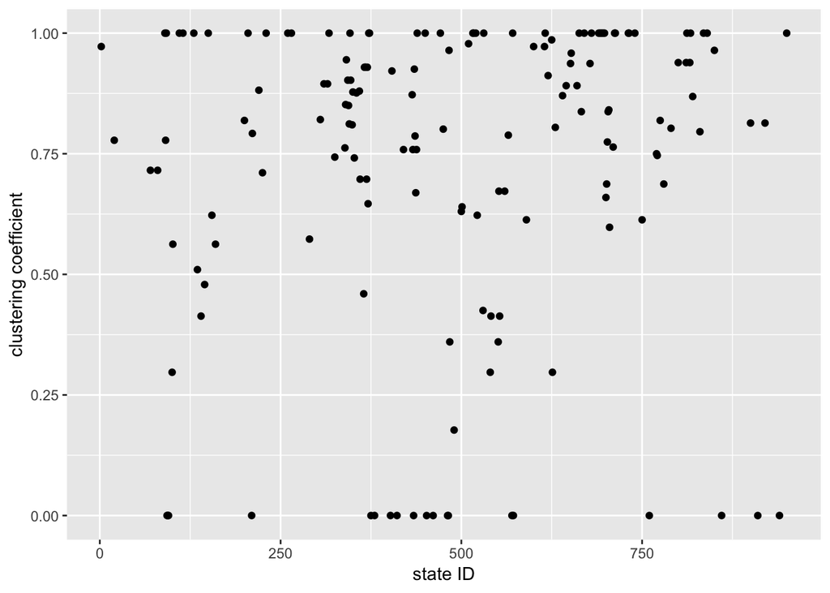

```r
test <- count_coef(g) # Get it for every state in the TEK network

ggplot(test, aes(x = gwid, y = coef^2)) +
geom_point() +
labs(x = "state ID", y = "clustering coefficient")
```

#### Define a helper function that returns the number of violence occurring in every state’s contact neighborhood for a given TEK network.

```r
count_nei_con <- function(g, df){ # g -> the network in this given year; df -> war data for the given year

    nei_cons <- data.frame() # Placeholder for neighbor counts
    for(state in V(g)$name){
        neighbors <- neighbors(g, state)$name # Get all the neighbors' names

        # If the state actually has neighbors...
        if(length(neighbors) != 0){
            t <- df %>% filter(gwid %in% neighbors)
            t <- sum(t$incidence_all) # Calculate the neighborhood in this given year
        }

        # If no neighbors at all
        else{
            t <- 0
        }
        dft <- data.frame(gwid = as.numeric(state),
                          nei_curr = as.numeric(t))

        nei_cons <- rbind(nei_cons, dft) # Add to the list of numbers
    }
    return(nei_cons)
}
```

#### Define a helper function to get clustering coefs for all states in a given year.

```r
count_stuff <- function(df, y){
    war_t <- df %>% filter(year == y) %>% group_by(gwid) %>% summarize(year = y, incidence_all = sum(incidence_flag)) %>% ungroup()

    t1 <- war_t %>% group_by(gwid) %>% summarize(year = y) %>% ungroup() # Make a placeholder for year

    ### Make graph objects with states in this year ###

    nodes_t <- inner_join(nodes_world, war_t, by = 'gwid')
    tek_t <- tek %>% filter(gwid %in% nodes_t$gwid) # Get the TEK data for states that were on record during this year segment

    nodes <- data.frame(id = nodes_t$gwid,
                        title = nodes_t$statename)

    # Get edgelist
    route_t <- get_edge_list(tek_t)
    edges <- data.frame(from = route_t$sourceid,
                        to = route_t$desid,
                        group = route_t$groupnames)

    # Make an igraph object
    g <- graph_from_data_frame(edges, directed = FALSE, vertices = nodes)

    # 1. count the clustering coefs in this graph
    clr_coef <- count_coef(g)
    # Add it on to placeholder t1
    t1 <- inner_join(t1, clr_coef, by = 'gwid')

    # 2. count the number of neighbors in conflict
    t2 <- count_nei_con(g, war_t)

    temp <- merge(t1, t2, by = 'gwid')

    return(temp)
}
```

#### Construct the almost-final dataset using the above functions – it takes a while to run.

```r
vars <- data.frame()

for(y in 1960:2017){

    vars <- rbind(vars, count_stuff(war_final, y))
}

war_final <- left_join(war_final, vars, by = c('gwid', 'year'))
head(war_final)
```

```
## # A tibble: 6 x 16
##    gwid  year statename incidence_flag incidence_terr_… incidence_gov_f…
##   <dbl> <dbl> <chr>              <dbl>            <dbl>            <dbl>
## 1     2  1960 United S…              0                0                0
## 2     2  1961 United S…              0                0                0
## 3     2  1962 United S…              0                0                0
## 4     2  1963 United S…              0                0                0
## 5     2  1964 United S…              0                0                0
## 6     2  1965 United S…              0                0                0
## # … with 10 more variables: incidence_eth_flag <dbl>,
## #   incidence_terr_eth_flag <dbl>, incidence_gov_eth_flag <dbl>,
## #   warhist <dbl>, peaceyears <dbl>, scode <chr>, polity <dbl>,
## #   pcgdp <dbl>, coef <dbl>, nei_curr <dbl>
```

#### Further data processing: address missing data

```r
# Get the number of conflicts in neighborhood the previous year
f1 <- data.frame()
for(y in 1960:2017){
    war_curr <- war_final %>% filter(year == y)
    war_prev <- war_final %>% filter(year == y-1) %>% select(gwid, nei_prev = nei_curr)
    war_curr <- left_join(war_curr, war_prev, by = 'gwid')
    war_curr[is.na(war_curr$nei_prev),]$nei_prev <- 0
    f1 <- rbind(f1, war_curr)
}

# Get the conflict dummy of the state itself the previous year
final <- data.frame()
for(y in 1961:2017){
    war_curr <- f1 %>% filter(year == y)
    war_prev <- f1 %>% filter(year == y-1) %>% select(gwid, ego_prev = incidence_flag)
    war_curr <- left_join(war_curr, war_prev, by = 'gwid')
    final <- rbind(final, war_curr)
}

# Address missing values in neighbor conflict counts and clustering coefs with 0
final[is.na(final$nei_curr),]$nei_curr <- 0
final[is.na(final$coef),]$coef <- 0

# Address some NA in pcgdp with mean
t <- final %>% group_by(gwid) %>% summarize(rpl = mean(pcgdp, na.rm = TRUE)) %>% ungroup()
final <- left_join(final, t, by = 'gwid')
final$pcgdp[is.na(final$pcgdp)] <- final$rpl[is.na(final$pcgdp)]
final <- final[,1:(ncol(final)-1)]

# Do the same for polity
t <- final %>% group_by(gwid) %>% summarize(rpl = mean(polity, na.rm = TRUE)) %>% ungroup()
final <- left_join(final, t, by = 'gwid')
final$polity[is.na(final$polity)] <- final$rpl[is.na(final$polity)]
final <- final[,1:(ncol(final)-1)]

# Drop everything without polity score and ego_prev
final <- final[!is.na(final$polity), ]
final <- final[!is.na(final$ego_prev), ]

head(final)
```

```
## # A tibble: 6 x 18
##    gwid  year statename incidence_flag incidence_terr_… incidence_gov_f…
##   <dbl> <dbl> <chr>              <dbl>            <dbl>            <dbl>
## 1     2  1961 United S…              0                0                0
## 2    20  1961 Canada                 0                0                0
## 3    40  1961 Cuba                   1                0                1
## 4    41  1961 Haiti                  0                0                0
## 5    42  1961 Dominica…              0                0                0
## 6    70  1961 Mexico                 0                0                0
## # … with 12 more variables: incidence_eth_flag <dbl>,
## #   incidence_terr_eth_flag <dbl>, incidence_gov_eth_flag <dbl>,
## #   warhist <dbl>, peaceyears <dbl>, scode <chr>, polity <dbl>,
## #   pcgdp <dbl>, coef <dbl>, nei_curr <dbl>, nei_prev <dbl>,
## #   ego_prev <dbl>
```

Have a look at the missing calues again.

```r
sapply(final, function(x) sum(is.na(x)))
```

```
##                    gwid                    year               statename
##                       0                       0                       0
##          incidence_flag     incidence_terr_flag      incidence_gov_flag
##                       0                       0                       0
##      incidence_eth_flag incidence_terr_eth_flag  incidence_gov_eth_flag
##                       0                       0                       0
##                 warhist              peaceyears                   scode
##                       0                       0                     189
##                  polity                   pcgdp                    coef
##                       0                    4580                       0
##                nei_curr                nei_prev                ego_prev
##                       0                       0                       0
```

#### I DON’T KNOW HOW TO ADDRESS THE FOLLOWING MISSING DATA. THIS METHOD IS TEMPORARY

```r
final[is.na(final$pcgdp),]$pcgdp <- 500
```

#### **WORKING PROCESS** Exploratory analysis

```r
final <- final %>% mutate(coef_sq = coef^2)
```

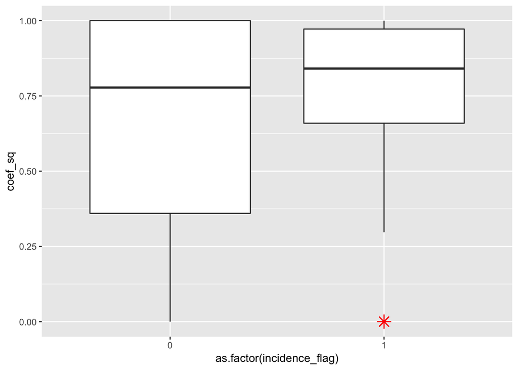

```r
ggplot(final, aes(x = as.factor(incidence_flag), y = coef_sq)) +
geom_boxplot(outlier.colour="red",
             outlier.shape=8,
             outlier.size=4)
```

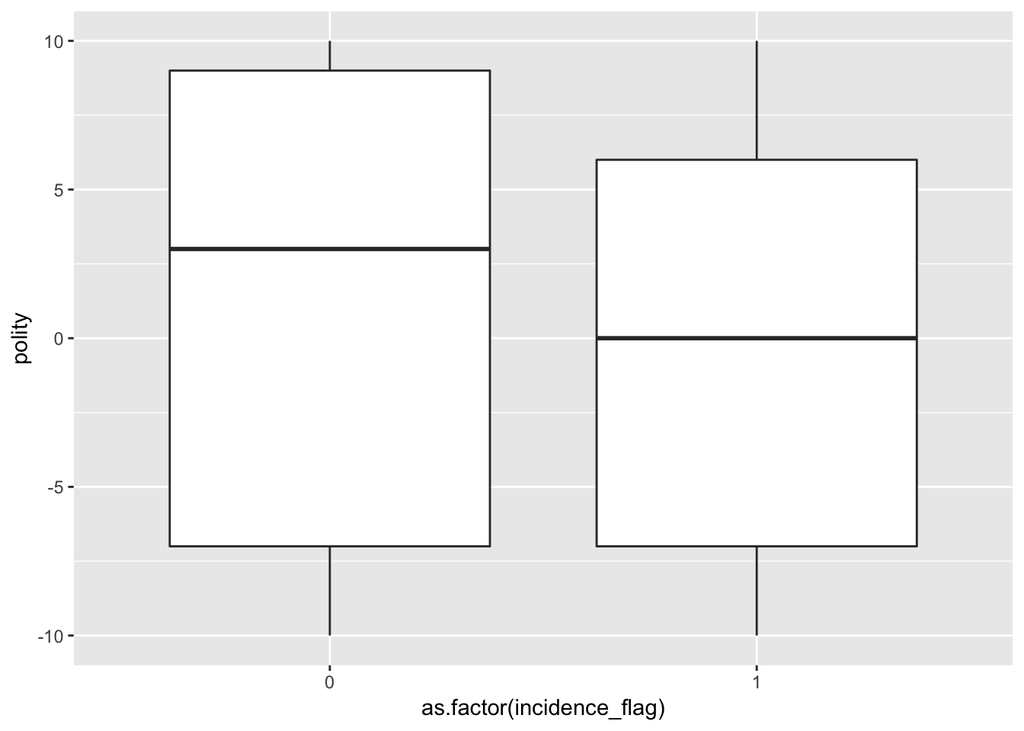

```r
ggplot(final, aes(x = as.factor(incidence_flag), y = polity)) +
geom_boxplot(outlier.colour="red",
             outlier.shape=8,
             outlier.size=4)
```

### **WORKING PROCESS** Model Construction And Evaluation

```r
# Baseline model
fit_base <- glm(as.factor(incidence_flag) ~ polity + log(pcgdp), data = final, family = "binomial")
summary(fit_base)
```

```
##
## Call:
## glm(formula = as.factor(incidence_flag) ~ polity + log(pcgdp),
##     family = "binomial", data = final)
##
## Deviance Residuals:
##     Min       1Q   Median       3Q      Max
## -0.7581  -0.6516  -0.5970  -0.4687   2.2385
##
## Coefficients:
##              Estimate Std. Error z value Pr(>|z|)
## (Intercept) -0.411184   0.169916  -2.420   0.0155 *
## polity      -0.017208   0.004135  -4.161 3.16e-05 ***
## log(pcgdp)  -0.169133   0.024234  -6.979 2.97e-12 ***
## ---
## Signif. codes:  0 '***' 0.001 '**' 0.01 '*' 0.05 '.' 0.1 ' ' 1
##
## (Dispersion parameter for binomial family taken to be 1)
##
##     Null deviance: 7497.7  on 8317  degrees of freedom
## Residual deviance: 7408.2  on 8315  degrees of freedom
## AIC: 7414.2
##
## Number of Fisher Scoring iterations: 4
```

```r
# Trial a
fit_a <- glm(as.factor(incidence_flag) ~ polity + log(pcgdp) + ego_prev, data = final, family = "binomial")
summary(fit_a)
```

```
##
## Call:
## glm(formula = as.factor(incidence_flag) ~ polity + log(pcgdp) +
##     ego_prev, family = "binomial", data = final)
##
## Deviance Residuals:
##     Min       1Q   Median       3Q      Max
## -2.0303  -0.2747  -0.2540  -0.2231   2.7662
##
## Coefficients:
##              Estimate Std. Error z value Pr(>|z|)
## (Intercept) -2.783332   0.286188  -9.726   <2e-16 ***
## polity      -0.013279   0.007429  -1.787   0.0739 .
## log(pcgdp)  -0.082903   0.039673  -2.090   0.0366 *
## ego_prev     5.053296   0.100609  50.227   <2e-16 ***
## ---
## Signif. codes:  0 '***' 0.001 '**' 0.01 '*' 0.05 '.' 0.1 ' ' 1
##
## (Dispersion parameter for binomial family taken to be 1)
##
##     Null deviance: 7497.7  on 8317  degrees of freedom
## Residual deviance: 3180.4  on 8314  degrees of freedom
## AIC: 3188.4
##
## Number of Fisher Scoring iterations: 6
```

```r
# Trial b
fit_b <- glm(as.factor(incidence_flag) ~ polity + log(pcgdp) + ego_prev + nei_prev + nei_curr, data = final, family = "binomial")
summary(fit_b)
```

```
##
## Call:
## glm(formula = as.factor(incidence_flag) ~ polity + log(pcgdp) +
##     ego_prev + nei_prev + nei_curr, family = "binomial", data = final)
##
## Deviance Residuals:
##     Min       1Q   Median       3Q      Max
## -2.4847  -0.2656  -0.2345  -0.2023   2.8307
##
## Coefficients:
##              Estimate Std. Error z value Pr(>|z|)
## (Intercept) -2.842908   0.293732  -9.679  < 2e-16 ***
## polity      -0.002504   0.007647  -0.327  0.74329
## log(pcgdp)  -0.119300   0.041278  -2.890  0.00385 **
## ego_prev     4.959231   0.101087  49.059  < 2e-16 ***
## nei_prev     0.018268   0.056658   0.322  0.74713
## nei_curr     0.104367   0.055269   1.888  0.05898 .
## ---
## Signif. codes:  0 '***' 0.001 '**' 0.01 '*' 0.05 '.' 0.1 ' ' 1
##
## (Dispersion parameter for binomial family taken to be 1)
##
##     Null deviance: 7497.7  on 8317  degrees of freedom
## Residual deviance: 3134.5  on 8312  degrees of freedom
## AIC: 3146.5
##
## Number of Fisher Scoring iterations: 6
```

```r
# Trial c
fit_c <- glm(as.factor(incidence_flag) ~ polity + log(pcgdp)+ coef_sq + ego_prev + nei_prev + nei_curr + coef_sq:nei_prev, data = final, family = "binomial")
summary(fit_c)
```

```
##
## Call:
## glm(formula = as.factor(incidence_flag) ~ polity + log(pcgdp) +
##     coef_sq + ego_prev + nei_prev + nei_curr + coef_sq:nei_prev,
##     family = "binomial", data = final)
##
## Deviance Residuals:
##     Min       1Q   Median       3Q      Max
## -2.7084  -0.2799  -0.2391  -0.1789   2.9224
##
## Coefficients:
##                   Estimate Std. Error z value Pr(>|z|)
## (Intercept)      -3.397681   0.333826 -10.178  < 2e-16 ***
## polity           -0.007449   0.007832  -0.951 0.341544
## log(pcgdp)       -0.105304   0.041552  -2.534 0.011267 *
## coef_sq           0.725873   0.198079   3.665 0.000248 ***
## ego_prev          4.912509   0.101370  48.461  < 2e-16 ***
## nei_prev          0.359813   0.103695   3.470 0.000521 ***
## nei_curr          0.101963   0.055631   1.833 0.066824 .
## coef_sq:nei_prev -0.417331   0.103517  -4.032 5.54e-05 ***
## ---
## Signif. codes:  0 '***' 0.001 '**' 0.01 '*' 0.05 '.' 0.1 ' ' 1
##
## (Dispersion parameter for binomial family taken to be 1)
##
##     Null deviance: 7497.7  on 8317  degrees of freedom
## Residual deviance: 3112.8  on 8310  degrees of freedom
## AIC: 3128.8
##
## Number of Fisher Scoring iterations: 6
```

Summary stats says that coef_sq, coef_sq:nei_prev interaction are both significant. ### Diagnostic

### Test Model Performance

```r
train_inds <- caret::createDataPartition(final$incidence_flag, p = 0.75)
train_val <- final %>% dplyr::slice(train_inds[[1]])
test <- final %>% dplyr::slice(-train_inds[[1]])

set.seed(19980224)
val_folds <- caret::createFolds(train_val$incidence_flag, k = 6)
```

We do 6-fold cross validation to test the accuracy for the final model.

```r
df_mse <- data.frame()
val_fold_num <- names(val_folds)

for (i in 1:length(val_fold_num)){
  temp <- data.frame()
  fold <- val_fold_num[i]

  # Get train val split
  val <- train_val %>% slice(val_folds[[fold]])
  train <- train_val %>% slice(-val_folds[[fold]])

  # Train the model
  fit_2 <- train(
    form = as.factor(incidence_flag) ~ polity + log(pcgdp)+ coef_sq + ego_prev + nei_prev + nei_curr + coef_sq:nei_prev,
    data = train,
    family = "binomial",
    method = "glm", # method for fit; "generalized linear model"
    trControl = trainControl(method = "none")
    )

  # Calculate validation set mse
  # Same deal with transformation
  test_hat <- predict(fit_2, newdata = val, type = "raw")
  val_mse <- mean(as.factor(val$incidence_flag) != test_hat)

  temp <- data.frame("Fold" = fold, val_mse)
  df_mse <- rbind(df_mse, temp)
  }
df_mse
```

```
##    Fold    val_mse
## 1 Fold1 0.05769231
## 2 Fold2 0.03269231
## 3 Fold3 0.05000000
## 4 Fold4 0.06538462
## 5 Fold5 0.05576923
## 6 Fold6 0.05582291
```

Try it on test set:

```r
fit <- train(
    form = as.factor(incidence_flag) ~ polity + log(pcgdp)+ coef_sq + ego_prev + nei_prev + nei_curr + coef_sq:nei_prev,
    data = train_val,
    family = "binomial",
    method = "glm", # method for fit; "generalized linear model"
    trControl = trainControl(method = "none")
)

test_hat <- predict(fit, newdata = test, type = "raw")
mean(as.factor(test$incidence_flag) != test_hat)
```

```
## [1] 0.05339105
```